# SCEG-HiC on paired scATAC-seq/RNA-seq data of PBMC (aggregation)

XuanLiang

Compiled: May 12, 2026

In this vignette, we demonstrate the capability of SCEG-HiC to infer enhancer–gene links by applying it to paired scATAC-seq/RNA-seq data. Specifically, we use a publicly available 10x Genomics Multiome dataset from human peripheral blood mononuclear cells (PBMCs), and process the data using the aggregation approach.

The implementation of SCEG-HiC is seamlessly compatible with the standard workflow of the Seurat/Signac packages. The SCEG-HiC pipeline consists of the following three main steps:

- **Set up the Seurat object**: Prepare and preprocess paired single-cell multi-omics data using the Seurat and Signac framework.
- **Infer enhancer–gene links**: Apply the SCEG-HiC model to the processed Seurat object, incorporating human bulk average Hi-C data as a chromatin conformation prior to enhance the inference of enhancer–gene links.
- **Visualize enhancer–gene links**: Generate graphical outputs such as arc diagrams and coverage plots to visualize predicted enhancer–gene links.

**View data download code**

You can download the required data by running the following commands in a shell:

```bash
wget https://cf.10xgenomics.com/samples/cell-arc/1.0.0/pbmc_granulocyte_sorted_10k/pbmc_granulocyte_sorted_10k_filtered_feature_bc_matrix.h5
wget https://cf.10xgenomics.com/samples/cell-arc/1.0.0/pbmc_granulocyte_sorted_10k/pbmc_granulocyte_sorted_10k_atac_fragments.tsv.gz
wget https://cf.10xgenomics.com/samples/cell-arc/1.0.0/pbmc_granulocyte_sorted_10k/pbmc_granulocyte_sorted_10k_atac_fragments.tsv.gz.tbi
```

## Load the required libraries

```r
library(SCEGHiC)
library(Signac)
library(Seurat)
library(EnsDb.Hsapiens.v86)
library(BSgenome.Hsapiens.UCSC.hg38)
library(ggplot2)
library(hdf5r)
```

## Set up the Seurat Object

To facilitate easy exploration, `PBMC_multiomic.rds` file is also available at [10.5281/zenodo.14849886](https://zenodo.org/record/14849886).

**Note**: Due to the stochastic nature of `SCTransform`, particularly in generating `scale.data`, the UMAP embedding produced by re-running the code may differ slightly from that in the provided `PBMC_multiomic.rds` file.

### Generation of a multi-omics Seurat object with RNA and ATAC data

Construct a Seurat object combining RNA expression and ATAC-seq chromatin accessibility data and genome features from hg38.

```r
# Load RNA and ATAC data from 10X Genomics output files
counts <- Read10X_h5("pbmc_granulocyte_sorted_10k_filtered_feature_bc_matrix.h5")
fragpath <- "pbmc_granulocyte_sorted_10k_atac_fragments.tsv.gz"
```

```r
# Get gene annotations from EnsDb.Hsapiens.v86
# Add "chr" prefix to chromosome names to match peak naming conventions
annotation <- GetGRangesFromEnsDb(ensdb = EnsDb.Hsapiens.v86)
seqlevels(annotation) <- paste0("chr", seqlevels(annotation))

# Create a Seurat object containing the RNA count matrix (assay named "RNA")
pbmc <- CreateSeuratObject(
  counts = counts$`Gene Expression`,
  assay = "RNA"
)

# Create an ATAC assay using the filtered peak counts and annotations, and add it to the Seurat object
pbmc[["ATAC"]] <- CreateChromatinAssay(
  counts = counts$Peaks,
  sep = c(":", "-"),
  fragments = fragpath,
  annotation = annotation
)
```

```r
# Display summary of the Seurat object
pbmc
```

```
## An object of class Seurat
## 144978 features across 11909 samples within 2 assays
## Active assay: RNA (36601 features, 0 variable features)
##  1 layer present: counts
##  1 other assay present: ATAC
```

### Quality control and filtering

Calculate QC metrics (RNA counts, ATAC counts, nucleosome signal, TSS enrichment) and filter low-quality cells using defined thresholds.

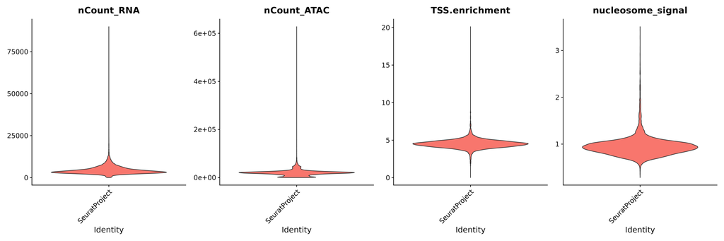

```r
# Set default assay to ATAC for ATAC-seq quality metrics calculation
DefaultAssay(pbmc) <- "ATAC"

# Calculate nucleosome signal score, which reflects nucleosome positioning
pbmc <- NucleosomeSignal(pbmc)

# Calculate Transcription Start Site (TSS) enrichment score for each cell, a metric for ATAC-seq data quality
pbmc <- TSSEnrichment(pbmc)

# Plot violin plots for QC metrics:
# - RNA counts per cell (nCount_RNA)
# - ATAC counts per cell (nCount_ATAC)
# - TSS enrichment score (TSS.enrichment)
# - Nucleosome signal score (nucleosome_signal)
VlnPlot(
  object = pbmc,
  features = c("nCount_RNA", "nCount_ATAC", "TSS.enrichment", "nucleosome_signal"),
  ncol = 4,
  pt.size = 0
)
```

```r
# Filter out low-quality cells based on multiple QC thresholds
pbmc <- subset(
  x = pbmc,
  subset = nCount_ATAC < 100000 &
    nCount_RNA < 25000 &
    nCount_ATAC > 1000 &
    nCount_RNA > 1000 &
    nucleosome_signal < 2 &
    TSS.enrichment > 1
)

# Print summary of the filtered Seurat object
pbmc
```

```
## An object of class Seurat
## 144978 features across 11331 samples within 2 assays
## Active assay: ATAC (108377 features, 0 variable features)
##  2 layers present: counts, data
##  1 other assay present: RNA
```

### Peak calling and quantification

Call peaks, filter, count fragments per peak, and add to Seurat object.

```r
# Call peaks using MACS2 from the fragments in the Seurat object
peaks <- CallPeaks(pbmc)

# Remove peaks on nonstandard chromosomes and in genomic blacklist regions
peaks <- keepStandardChromosomes(peaks, pruning.mode = "coarse")
peaks <- subsetByOverlaps(x = peaks, ranges = blacklist_hg38_unified, invert = TRUE)

# Quantify counts of fragments overlapping each peak for each cell, creating a peak-by-cell count matrix
macs2_counts <- FeatureMatrix(
  fragments = Fragments(pbmc),
  features = peaks,
  cells = colnames(pbmc)
)
```

```
## Extracting reads overlapping genomic regions
```

```r
# Create a new chromatin assay based on MACS2-called peaks and add it to the Seurat object
pbmc[["peaks"]] <- CreateChromatinAssay(
  counts = macs2_counts,
  fragments = fragpath,
  annotation = annotation
)
```

```
## Computing hash
```

```r
# Print summary of the updated Seurat object
pbmc
```

```
## An object of class Seurat
## 276342 features across 11331 samples within 3 assays
## Active assay: ATAC (108377 features, 0 variable features)
##  2 layers present: counts, data
##  2 other assays present: RNA, peaks
```

### RNA analysis

Normalize RNA data with SCTransform and perform PCA for dimensionality reduction.

```r
# Set the default assay to "RNA" for RNA-based analysis
DefaultAssay(pbmc) <- "RNA"

# Perform normalization and variance stabilization using SCTransform
# This replaces traditional log-normalization and identifies variable features
pbmc <- SCTransform(pbmc)

# Run Principal Component Analysis (PCA) on the normalized data
# PCA reduces dimensionality while preserving major sources of variation
pbmc <- RunPCA(pbmc)
```

### ATAC analysis

Identify highly accessible peaks and perform dimensionality reduction using TF-IDF and SVD (LSI).

```r
# Set the default assay to "peaks" (i.e., the MACS2-called peak matrix)
DefaultAssay(pbmc) <- "peaks"

# Identify top features (peaks) based on accessibility; only keep peaks present in at least 5 cells
pbmc <- FindTopFeatures(pbmc, min.cutoff = 5)

# Perform Term Frequency-Inverse Document Frequency (TF-IDF) normalization
pbmc <- RunTFIDF(pbmc)

# Perform dimensionality reduction using Singular Value Decomposition (SVD), also referred to as Latent Semantic Indexing (LSI) in this context
pbmc <- RunSVD(pbmc)
```

### Cell type annotation and integration analysis

We use an annotated PBMC reference dataset from [Hao et al. (2020)](https://doi.org/10.1016/j.cell.2021.04.048) to perform cell type annotation and integration. The reference dataset is publicly available at: https://atlas.fredhutch.org/data/nygc/multimodal/pbmc_multimodal.h5seurat.

```r
# Load necessary library for working with Seurat h5Seurat format
library(SeuratDisk)

# Load multimodal PBMC reference dataset (processed with spca and SCT)
reference <- LoadH5Seurat("pbmc_multimodal.h5seurat", assays = list("SCT" = "counts"), reductions = "spca")

# Ensure the reference object is compatible with current Seurat version
reference <- UpdateSeuratObject(reference)

# Set the default assay for the query object to SCT (if applicable)
DefaultAssay(pbmc) <- "SCT"

# Identify anchors between the reference and the query using spca
transfer_anchors <- FindTransferAnchors(
  reference = reference,
  query = pbmc,
  normalization.method = "SCT",
  reference.reduction = "spca",
  recompute.residuals = FALSE,
  dims = 1:50
)

# Transfer cell type annotations from reference to query based on anchors
predictions <- TransferData(
  anchorset = transfer_anchors,
  refdata = reference$celltype.l1,
  weight.reduction = pbmc[["pca"]],
  dims = 1:50
)

# Store the predicted cell types in the metadata of the query object
pbmc <- AddMetaData(
  object = pbmc,
  metadata = predictions
)

# Set cell identities to the predicted labels
Idents(pbmc) <- "predicted.id"

# Set the display order of cell types
levels(pbmc) <- c("CD4 T", "CD8 T", "Mono", "NK", "B", "DC", "other T", "other")
```

Using [Seurat v4](https://doi.org/10.1016/j.cell.2021.04.048)’s weighted nearest neighbor method, we integrate gene expression and chromatin accessibility into a joint neighbor graph and create a unified UMAP embedding combining RNA and ATAC data.

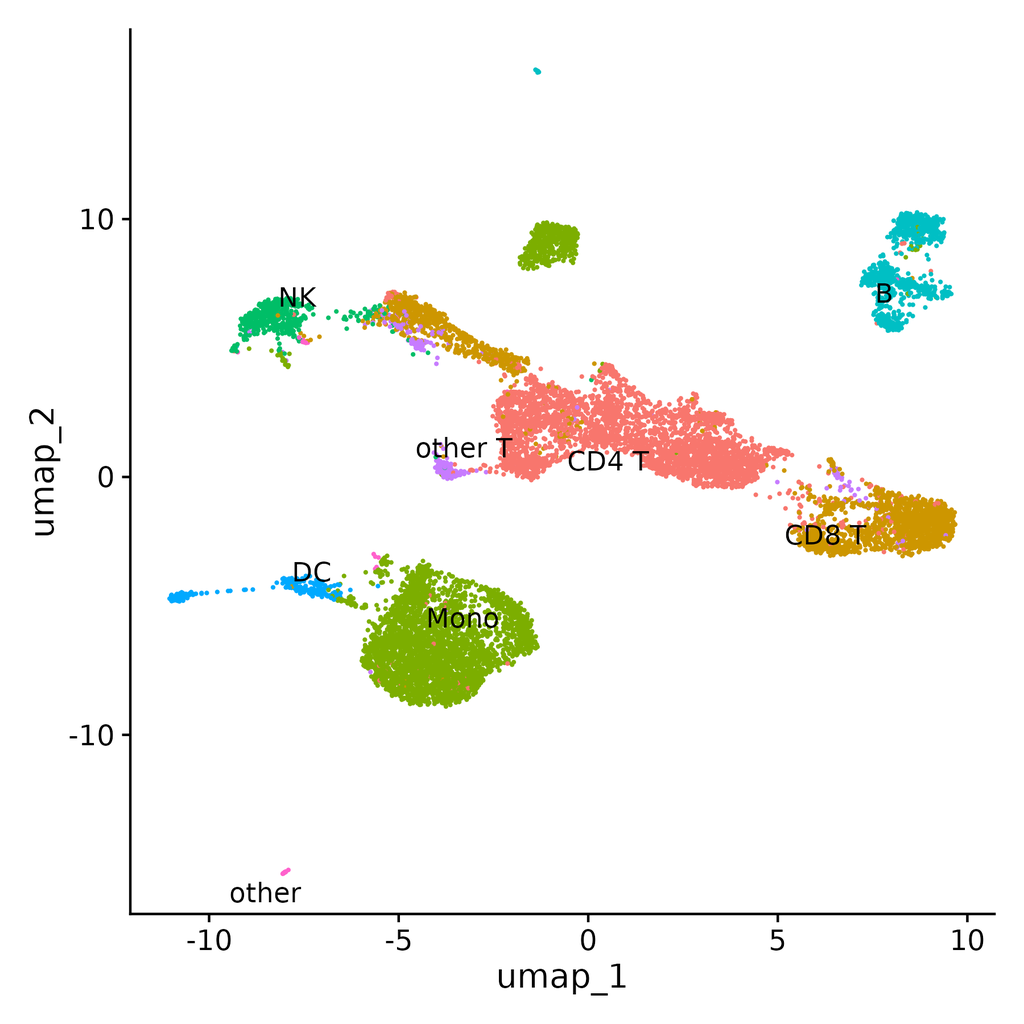

```r
# Build a multimodal nearest-neighbor graph using PCA from RNA and LSI from ATAC
pbmc <- FindMultiModalNeighbors(
  object = pbmc,
  reduction.list = list("pca", "lsi"),
  dims.list = list(1:50, 2:40),
  modality.weight.name = "RNA.weight",
  verbose = TRUE
)

# Generate a joint UMAP embedding using the WNN graph
# The embedding combines information from both RNA and ATAC modalities
pbmc <- RunUMAP(
  object = pbmc,
  nn.name = "weighted.nn",
  assay = "RNA",
  verbose = TRUE
)

DimPlot(pbmc, label = TRUE, repel = TRUE, reduction = "umap") + NoLegend()
```

## Infer enhancer–gene links

### Preprocess data

When preprocessing data with SCEG-HiC, you can choose either aggregation or single-cell retention approach, and use either paired scATAC-seq/RNA-seq or scATAC-seq data alone. Here, we process paired scATAC-seq/RNA-seq data stored in a Seurat object using the aggregation approach. By default, the scATAC-seq counts are binarized to indicate the presence or absence of chromatin accessibility at each peak.

```r
# Prepare input data for SCEG-HiC analysis
# This function processes paired scATAC-seq/RNA-seq data stored in a Seurat object
SCEGdata <- process_data(pbmc, max_overlap = 0.5)
```

```
## Generating aggregated data
```

```
## Aggregating cluster CD4 T
```

```
## Sample cells randomly.
```

```
## There are 76 samples
```

```
## Aggregating cluster CD8 T
```

```
## Sample cells randomly.
```

```
## There are 43 samples
```

```
## Aggregating cluster Mono
```

```
## Sample cells randomly.
```

```
## There are 79 samples
```

```
## Aggregating cluster NK
```

```
## Sample cells randomly.
```

```
## There are 12 samples
```

```
## Aggregating cluster B
```

```
## Sample cells randomly.
```

```
## There are 20 samples
```

```
## Aggregating cluster DC
```

```
## Sample cells randomly.
```

```
## There are 6 samples
```

```
## Aggregating cluster other T
```

```
## Sample cells randomly.
```

```
## There are 6 samples
```

```
## Aggregating cluster other
```

```
## Skipping group other (not enough cells)
```

### Calculate weight

Calculating weights with SCEG-HiC can be time-consuming, especially as the number of selected genes increases. To facilitate this process, SCEG-HiC provides downloadable average Hi-C datasets for both human and mouse (detail [here](https://wuwei77lx.github.io/SCEGHiC/index.html#the-bulk-average-hi-c)). In this case, we select the human average Hi-C data as prior information to calculate enhancer-gene links weights.

**Select highly variable features**

You can focus on the top 3000 highly variable genes identified by SCTransform normalization:

```r
# Extract highly variable genes
gene <- pbmc@assays[["SCT"]]@var.features

# Calculate Hi-C weights for these genes using human average Hi-C data
weight <- calculateHiCWeights(SCEGdata, species = "Homo sapiens", genome = "hg38", focus_gene = gene, averHicPath = "/mnt/netshare2/liangxuan/data/human_contact/AvgHiC")
```

As an example, we calculate Hi-C weights focusing on PDK1, a key regulator of T cell development and activation.

```r
# Alternatively, calculate Hi-C weights for PDK1
weight <- calculateHiCWeights(SCEGdata, species = "Homo sapiens", genome = "hg38", focus_gene = "PDK1", averHicPath = "/mnt/netshare2/liangxuan/data/human_contact/AvgHiC")
```

```
## Processing chromosome chr2...
```

```
## Found 1 TSS loci on chr2.
```

```
## Calculating Hi-C weights for gene PDK1...
```

```
## Finished calculating Hi-C weights for all genes.
```

### Run model

SCEG-HiC employs the wglasso method to infer enhancer-gene links by integrating processed single-cell multi-omics data and normalized bulk average Hi-C contact matrices. The bulk Hi-C matrix is normalized using rank score to improve accuracy. In this example, we run the model focusing on genes PDK1 to identify their putative enhancer links.

```r
# Example: Run the model focused on PDK1
results_SCEGHiC <- Run_SCEG_HiC(SCEGdata, weight, focus_gene = "PDK1")
```

```
## Total predicted genes: 1
```

```
## Running model for gene: PDK1
```

```
## [1] "The optimal penalty parameter (rho) selected by BIC is: 0.21"
```

## Visualize enhancer–gene links

### Arc plot visualization of enhancer-gene links

Arc plot visualizes the predicted links between enhancers and target genes as arcs connecting genomic regions, highlighting spatial chromatin interactions inferred by SCEG-HiC.

Arc plot visualization of enhancer-gene links for PDK1.

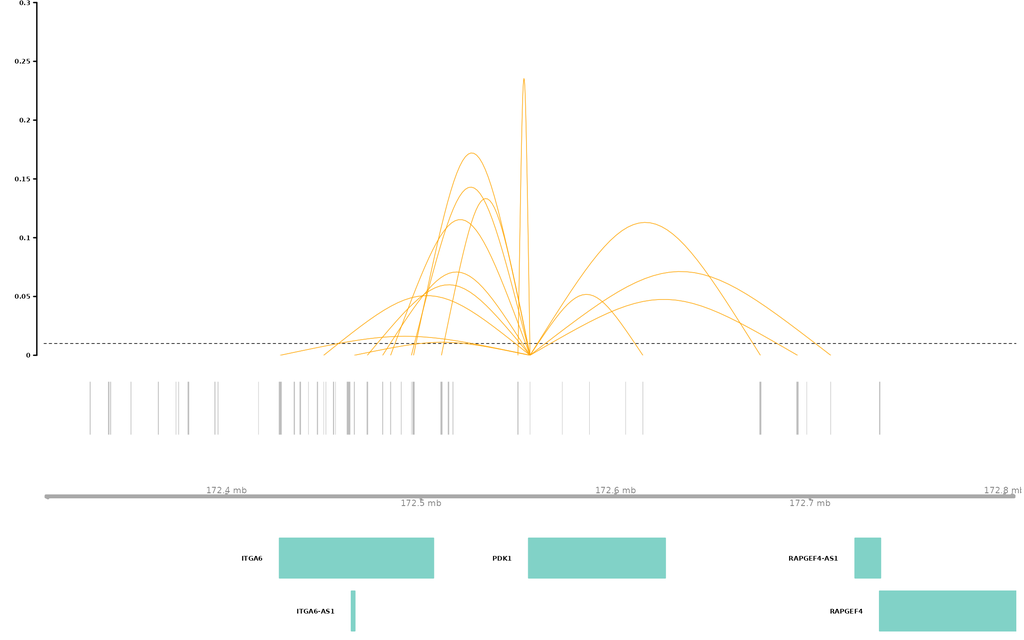

```r
# Download and prepare gene annotation data
# wget https://hgdownload2.soe.ucsc.edu/goldenPath/hg38/bigZips/genes/hg38.refGene.gtf.gz
temp <- "hg38.refGene.gtf.gz"
gene_anno <- rtracklayer::readGFF(temp)

# Rename some columns to match requirements
gene_anno$chromosome <- gene_anno$seqid
gene_anno$gene <- gene_anno$gene_id
gene_anno$transcript <- gene_anno$transcript_id
gene_anno$symbol <- gene_anno$gene_name

# Arc plot visualization of enhancer-gene links for PDK1
connections_Plot(results_SCEGHiC, species = "Homo sapiens", genome = "hg38", focus_gene = "PDK1", cutoff = 0.01, gene_anno = gene_anno)
```

### Coverage plot visualization of enhancer-gene links with Hi-C (or eQTL) validation

Coverage Plot visualizes chromatin accessibility around a target gene, including Hi-C interactions, scATAC-seq signals, aggregated ATAC-RNA correlations, eQTL SNPs, and enhancer–gene links predicted by SCEG-HiC. This facilitates intuitive comparison of regulatory interactions across multiple data layers.

Here, the ground truth for CD4+ T cells is obtained from the [ENCODE database](https://www.encodeproject.org/files/ENCFF762HKR/@@download/ENCFF762HKR.hic), and the correlation is calculated as the Pearson correlation coefficient between each gene and its candidate enhancers. The detailed code for this analysis is publicly available at the [GitHub repository](https://github.com/wuwei77lx/compare_model).

Coverage plot and visualize the links of PDK1.

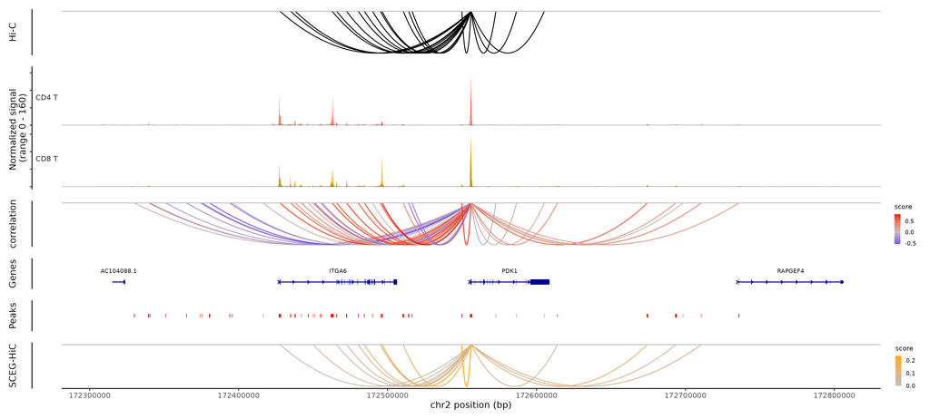

```r
# Load the truth of CD4+ T data
truth_CD4 <- readRDS("truth_CD4.rds")

## Load correlation data
correlation <- readRDS("correlation_CD4.rds")

# Coverage plot and visualize the links of PDK1
coverPlot(pbmc, focus_gene = "PDK1", species = "Homo sapiens", genome = "hg38", assay = "peaks", HIC_Result = truth_CD4, SCEG_HiC_Result = results_SCEGHiC, SCEG_HiC_cutoff = 0.01, correlation = correlation, cells = c("CD4 T", "CD8 T"))
```